# Test dobre shody

Overeni shody s danym rozdelenim.

## Diskretni rozdeleni

Pearsonuv test - test dobre shody Shoda s diskretnim a spojitym rozdelenim !! (chyby na testech). I na jiny testovani to slouzi (nezavislost znaku v kontingencni tabulce).

Zda je kostka OK, nebo falesna. H0: shoda s rovnomernym diskretnim rozdelenim. Hodnoty sou 1-6, p = 1/6.

```r
# patru tam i teoreticke pravdepodobnosti, u rovnomernyho rozdeleni to byt nemusi.
d1 <- c(122, 61, 98, 115, 79, 125)
test <- chisq.test(d1)
test
```

```
    Chi-squared test for given probabilities

data:  d1
X-squared = 33, df = 5, p-value = 3.763e-06
```

p value je velmi mala, < 0.05, zamitam H0, kostka je cinkla.

```r
# ?? nejakej rozdil lehkej, asi nepouzivat
chisq.test(d1, simulate.p.value = T)
```

```
    Chi-squared test for given probabilities with simulated p-value (based
    on 2000 replicates)

data:  d1
X-squared = 33, df = NA, p-value = 0.0004998
```

Priklad s teoretickejma pravdepodobnostma.

Pocas 100 dni sme sledovali pocty roztrhnuti vlakej (Poass) na stroji po generalni oprave. Ridi se to Poassonovym rozdelenim, stredni hodnota je 3 (za 1 den 3 roztrzeni). Overte shodu s danym rozdelenim.

```r
data <- c(rep(0, 4), rep(1, 10), rep(2, 26), rep(3, 27), rep(4, 13), rep(5, 10), rep(6, 4), rep(7, 4), rep(8, 2))
tab <- table(data)
d1 <- c(4, 10, 26, 27, 13, 10, 4, 4, 2) # pocetnosti empiricke
```

p0, p1, … p7, 1- sum(all)

```r
pp <- dpois(0:7, 3)
pp[9] <- 1 - sum(pp) # 8 a vic
```

```r
length(d1); length(pp)
```

```
[1] 9
```

```
[1] 9
```

```r
chisq.test(d1, pp)
```

```
    Pearson's Chi-squared test

data:  d1 and pp
X-squared = 36, df = 35, p-value = 0.4215
```

```r
chisq.test(d1, p = pp, simulate.p.value = T)
```

```
    Chi-squared test for given probabilities with simulated p-value (based
    on 2000 replicates)

data:  d1
X-squared = 6.5369, df = NA, p-value = 0.5867
```

```r
# p hodnota je > 0.05, nezamitam H0, data se ridi poissonovym rozdelenim.
```

S odhadnutou lambdou z namerenych dat zkusime jeste jednou

```r
l <- mean(data); l
```

```
[1] 3.13
```

```r
pp <- dpois(0:7, l)
pp[9] <- 1 - sum(pp) # 8 a vic
chisq.test(d1, p = pp, simulate.p.value = T)
```

```
    Chi-squared test for given probabilities with simulated p-value (based
    on 2000 replicates)

data:  d1
X-squared = 5.7084, df = NA, p-value = 0.6662
```

## Spojity rozdeleni

Kolmogorov-Smirgov test dobre shody - shoda se spojitym rozdelenim. Ma vetsi silu. Vyzaduje znalost parametru. Shoda s teoretickym spojitym rozdelenim. Udela se empiricka distribucni funkce. Pak supremelne rozdily.

Je i s modifikaci - lilierofs test s jinyma hranicnima hodnotama., pokus bysme neznali parametry.

```r
d1 <- c(19.32, 19.57, 19.08, 20.87, 19.9, 18.92, 20.98, 20.18,
        20.67, 18.87, 21.69, 19.9, 19.16, 20.44, 21.68, 21.23,
        19.44, 19.95, 20.59, 20.62, 21.05, 20, 18.96, 22.12, 19.39,
        19.85, 20.39, 18.93, 20.06, 19.2)
```

Greaficka analyza - boxplot

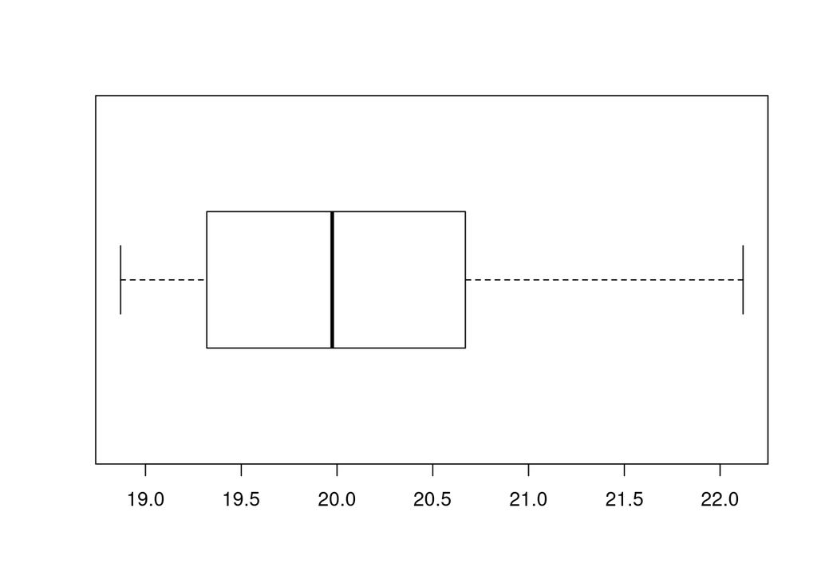

```r
boxplot(d1, horizontal = T)
```

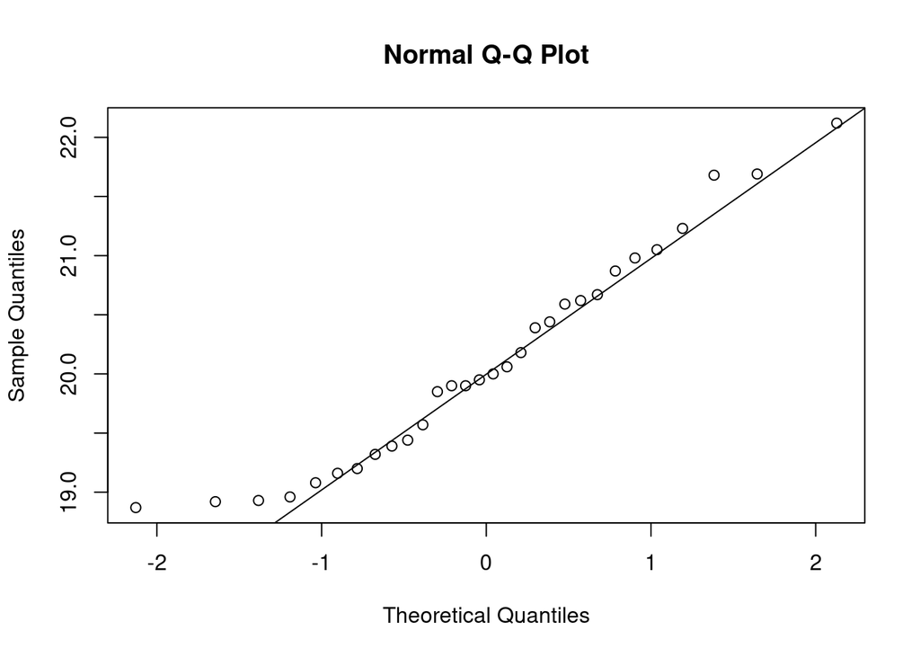

```r
# kvantil, kvantil, grafy
qqnorm(d1) # zhruba to lita na 1 ose.
qqline(d1)
```

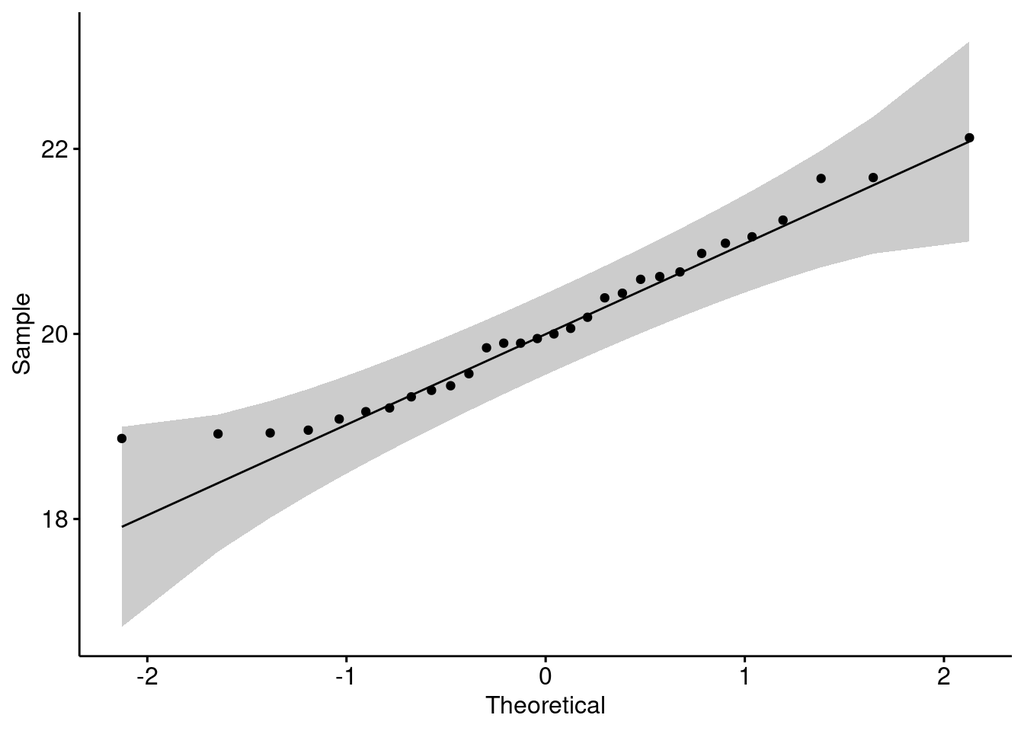

```r
library(ggpubr)
ggqqplot(d1) # tenhle best, interval spolehlivosti pro regresni primku. Dokad je to vevnitr, tak as OK.
```

Histogram empiricky a teoreticky hodnoty

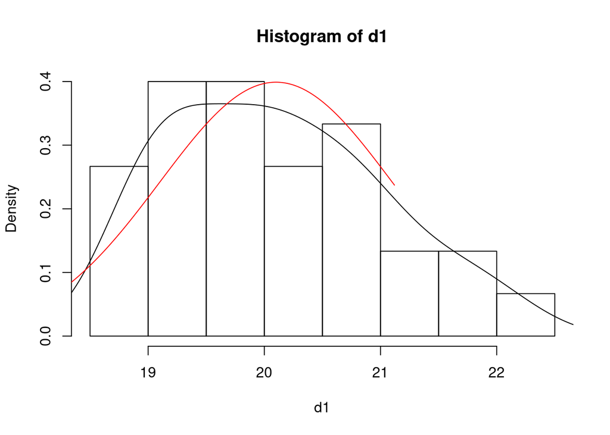

```r
hist(d1, probability = T)
lines(density(d1))
ssx <- seq(min(d1) - 1, max(d1) - 1, 0.01)
lines(ssx, dnorm(ssx, mean = mean(d1)), sd = sd(d1), col = 'red')
```

```r
test <- ks.test(d1, 'pnorm', mean = 20.1, sd = 0.9)
```

```r
l <- 1 / 2000
ziv <- c(4996, 976, 294, 7302, 2420, 1006, 7654, 2973, 320, 3169, 3994, 3989, 2689, 2215, 391, 4966, 1959, 9167, 5365, 2377)
test <- ks.test(ziv, 'pexp', 1 / 2000)
test
```

```
    One-sample Kolmogorov-Smirnov test

data:  ziv
D = 0.3745, p-value = 0.005002
alternative hypothesis: two-sided
```

Zamytam H0. Muze to byt jinym parametrem lambda.

Dvojvyberovy KS test. 2 labaky testuji pritomnost protilatek. Davaj labaky stejny vystupy?

```r
a <- c(0.28, 0.31, 0.27, 0.33, 0.33, 0.29, 0.29, 0.3, 0.31, 0.31, 0.32, 0.31, 0.3, 0.31, 0.3)
b <- c(0.24, 0.25, 0.28, 0.27, 0.2, 0.32, 0.13, 0.26, 0.38, 0.24, 0.36, 0.31, 0.3, 0.2, 0.26)

ks2 <- ks.test(a, b); ks2
```

```
    Two-sample Kolmogorov-Smirnov test

data:  a and b
D = 0.53333, p-value = 0.02806
alternative hypothesis: two-sided
```

Zamitam H0, ze mej stejny rozdeleni. Nemaj.

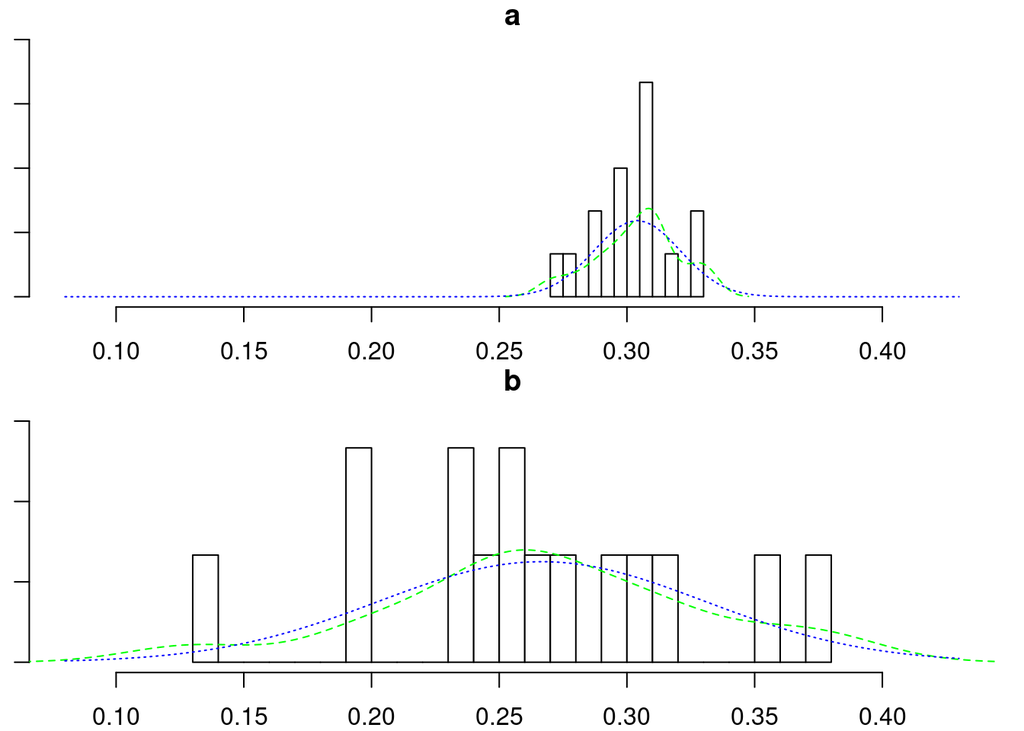

```r
library(psych)
data <- data.frame(a, b)
multi.hist(data, dcol = c('green', 'blue'))
```

Aj podle obrazku to vypada jinak.

Samostatne otestovat, ze to ma oboji normalni rozdeleni, parametry nezname -> pouze shappiro a lilienfors.

```r
# pro mensi rozsahy
# shapiro.test(a) # ano, sou normalne
# shapiro.test(b) # taky sou
#
# rozdil asi v rozptylech.

# pro vetsi rozsahy dat.
# lillie.test(a)
```